# Visualização de dados de transcriptômica espacial com PathwaySpace

Flávio Gabriel Carazza-Kessler

Sysbiolab Team

Mauro A. A. Castro

2026-05-18

# 1 Visão geral

Nesta vinheta, visualizaremos a expressão do gene `Camk2n1` na região anterior de uma seção de cérebro de camundongo. Primeiro, o sinal será observado diretamente nos spots com o `Seurat`. Em seguida, as coordenadas dos spots e a imagem histológica serão organizadas em um `GraphSpace`, a partir do qual o PathwaySpace produzirá uma representação contínua da expressão no tecido (Tercan et al. 2025).

O objeto de entrada é `data/brain.RDS`, produzido na etapa anterior do curso. O fluxo segue a ordem: inspeção do objeto, seleção da região anterior, escolha do gene, construção do espaço gráfico, projeção do sinal e comparação das visualizações.

A versão HTML apresenta o código e os resultados produzidos pela execução da análise. Durante o curso, você também pode abrir este arquivo `.Rmd` no RStudio e executar os blocos na ordem em que aparecem.

Essa vinheta segue o fluxo de trabalho apresentado na vinheta do pacote: [Visualizing spatial transcriptomics](https://sysbiolab.github.io/PathwaySpace/articles/spatial-transcriptomics.html).

# 2 Preparar o ambiente

## 2.1 Definir as pastas

Antes de executar o código, defina o diretório de trabalho como a pasta `vinhetas/`. No RStudio, use **Session > Set Working Directory > To Source File Location**. Será utilizado o objeto pré-processado da vinheta anterior, ele será carregado da pasta `data/` e a figura final será gravada em formato PNG na pasta `imagens/`.

```r
diretorio_vinhetas <- getwd()
diretorio_curso <- dirname(diretorio_vinhetas)
diretorio_dados <- file.path(diretorio_curso, "data")
diretorio_imagens <- file.path(diretorio_curso, "imagens")

dir.create(diretorio_imagens, showWarnings = FALSE, recursive = TRUE)
```

## 2.2 Conferir o PathwaySpace

A instalação do `PathwaySpace`, do `RGraphSpace` e das demais dependências está centralizada em [Configuracao_do_ambiente_RStudio.Rmd](https://flaviogckessler.github.io/Curso_ST/vinhetas/Configuracao_do_ambiente_RStudio.html). Depois de executar a primeira vinheta e reiniciar a sessão do R, use o bloco abaixo apenas para confirmar que o ambiente está pronto.

```r
pacotes_visualizacao <- c(
  "Seurat", "SeuratObject", "ggplot2", "patchwork", "gridExtra",
  "RGraphSpace", "PathwaySpace"
)

pacotes_ausentes <- pacotes_visualizacao[
  !vapply(pacotes_visualizacao, requireNamespace, logical(1), quietly = TRUE)
]

if (length(pacotes_ausentes) > 0) {
  stop(
    "Execute primeiro Configuracao_do_ambiente_RStudio.Rmd. ",
    "Pacotes ausentes: ",
    paste(pacotes_ausentes, collapse = ", ")
  )
}
```

## 2.3 Carregar os pacotes

```r
library("Seurat")
library("SeuratObject")
library("ggplot2")
library("RGraphSpace")
library("PathwaySpace")
library("patchwork")
```

# 3 Carregar e inspecionar o objeto espacial

O arquivo `brain.RDS` contém o objeto Seurat já processado nas etapas anteriores do curso, ele está localizado na pasta `data/`.

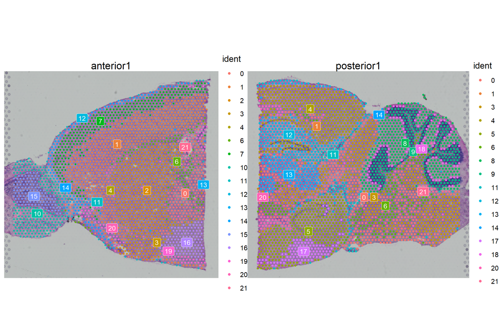

```r
brain <- readRDS(file.path(diretorio_dados, "brain.RDS"))

SpatialDimPlot(brain,label = TRUE,label.size = 3)
```

# 4 Selecionar a região anterior

Como a projeção será demonstrada em uma única seção histológica, manteremos somente os spots identificados como pertencentes à região anterior. A distribuição espacial dos clusters é exibida novamente após o recorte.

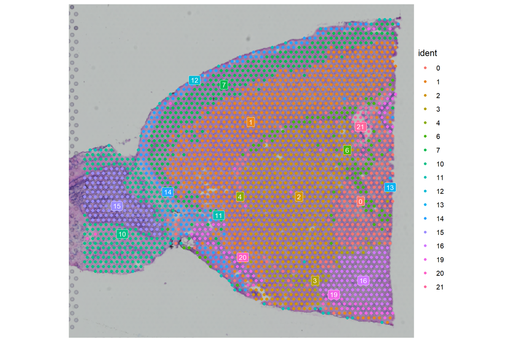

```r
brain <- subset(brain,subset = region == "anterior")

SpatialDimPlot(brain,
  label = TRUE,label.size = 3)
```

# 5 Selecionar e visualizar um gene de interesse

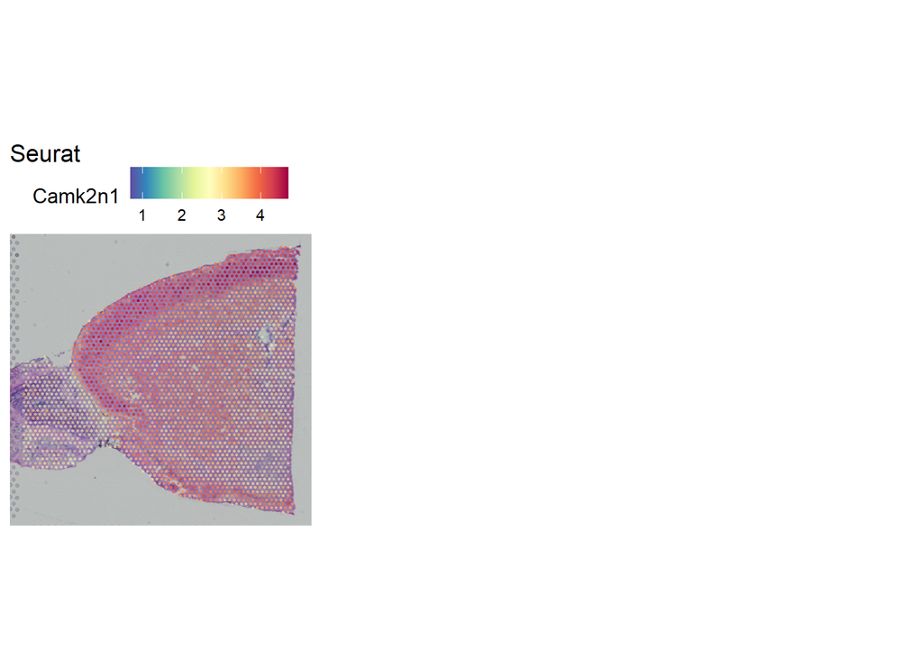

```r
gene <- "Camk2n1"

g_s <- SpatialFeaturePlot(brain,
  features = gene,ncol = 3,alpha = c(0.1, 1)) +
  labs(title = "Seurat")

g_s
```

# 6 Construir o espaço gráfico: RGraphSpace

O pacote [RGraphSpace](https://sysbiolab.github.io/RGraphSpace/articles/get-started.html) é um desenvolvimento do Sysbiolab (é do BR!). Ele possui funcionalidades de interface para plotagem de dados de transcriptômica espacial integrados com o `ggplot2`.

Além disso, ele constroi o objeto `GraphSpace` que depois será utilizado pelo próximo pacote (PathwaySpace) que irá realizar a visualização contínua.

## 6.1 Obter coordenadas, imagem e expressão

As coordenadas em baixa resolução posicionam os spots sobre a imagem histológica. A matriz da camada `data` fornece a expressão normalizada por transformação de estabilização da variância (VST) que será atribuída aos vértices do grafo.

```r
# Coordenadas dos spots
spot_coord <- GetTissueCoordinates(brain,scale = "lowres")

# Imagem histológica em formato raster
raster_image <- GetImage(brain,"raster")

# Expressão gênica normalizada por VST
vst_gexp <- GetAssayData(brain,layer = "data")
```

## 6.2 Criar e normalizar o `GraphSpace`

Cada spot será tratado como um vértice. O tamanho dos vértices é reduzido para facilitar a inspeção visual.

```r
spot_coord$nodeSize <- 1

# Para construir o objeto GraphSpace, se usa a função GraphSpace()
gs <- GraphSpace(spot_coord,)
```

```
#> Converting input data to an 'igraph' object...
#> Validating the 'igraph' object...
#> Creating a 'GraphSpace' object...
```

```r
# Atribuir imagem raster ao objeto
gs_image(gs) <- raster_image
# Atribuir a matriz de contagem ao objeto
gs_fdata(gs) <- vst_gexp
```

```
#> Feature matrix transposed: more node IDs found in columns than rows.
```

```r
gs
```

```
#> A GraphSpace-class object for:
#> IGRAPH d1b5dd5 UN-- 2696 0 --
#> + attr: x (v/n), y (v/n), name (v/c), nodeLabel (v/c), nodeSize (v/n),
#> | cell (v/c), arrowType (e/c)
#> + features: 18240 (Xkr4, Sox17, Mrpl15, Lypla1, ...)
#> + samples: 2696 (AAACAAGTATCTCCCA-1_1, AAACACCAATAACTGC-1_1, ...)
#> + node spatial boundaries: raw graph
#> | x: [76, 493] (cols)
#> | y: [138, 541] (rows)
#> + image spatial boundaries: raw image
#> | x: [1, 600] (cols)
#> | y: [1, 599] (rows)
```

## 6.3 Coerção e normalização do `GraphSpace`

Acima, foi demonstrada a contrução do objeto para fins educativos. Contudo o pacote já possui uma função de coerção do objeto `Seurat`, ou seja, ela extrai todos os dados do `Seurat` e converter automaticamente para o objeto `GraphSpace`. Esse de coreção é o fluxo recomendado por passar todos atributos que estavam armazenados no objeto `Seurat`.

Na sequência, a função `normalizeGraphSpace()` alinha as coordenadas cartesianas do grafo à orientação matricial da imagem. Assim, o RGraphSpace irá criar o “sistema de coordenadas normalizado” em que a imagem e as coordenas dos spots serão alinhados a nível do pixel.

```r
# Função de coerção do objeto Seurat
gs <- as.GraphSpace(brain, space = "spatial", scale = "lowres")
```

```
#> Coercing 'Seurat' to 'GraphSpace'...
#> Converting input data to an 'igraph' object...
#> Validating the 'igraph' object...
#> Creating a 'GraphSpace' object...
#> Adding 'layer' data to the 'GraphSpace' object...
```

```r
# Atribuir imagem raster ao objeto
gs_image(gs) <- SeuratObject::GetImage(brain, mode = "raster") # igual que raster_image
gs
```

```
#> A GraphSpace-class object for:
#> IGRAPH d275941 UN-- 2696 0 --
#> + attr: x (v/n), y (v/n), name (v/c), nodeLabel (v/c), nodeSize (v/n),
#> | cell (v/c), orig.ident (v/c), nCount_Spatial (v/n), nFeature_Spatial
#> | (v/n), slice (v/n), region (v/c), percent.mt (v/n), nCount_SCT (v/n),
#> | nFeature_SCT (v/n), SCT_snn_res.0.8 (v/x), seurat_clusters (v/x),
#> | arrowType (e/c)
#> + features: 18240 (Xkr4, Sox17, Mrpl15, Lypla1, ...)
#> + samples: 2696 (AAACAAGTATCTCCCA-1_1, AAACACCAATAACTGC-1_1, ...)
#> + node spatial boundaries: raw graph
#> | x: [76, 493] (cols)
#> | y: [138, 541] (rows)
#> + image spatial boundaries: raw image
#> | x: [1, 600] (cols)
#> | y: [1, 599] (rows)
```

```r
# Etapa de normalização.
gs <- normalizeGraphSpace(gs)
```

```
#> Normalizing node coordinates to image space...
#> Flipping y-coordinates over image center...
```

## 6.4 Conferir a sobreposição espacial

O gráfico abaixo sobrepõe os vértices à imagem do tecido. Se as coordenadas de outro conjunto estiverem invertidas no eixo vertical, o argumento `flip.y = TRUE` poderá ser usado em `normalizeGraphSpace()`.

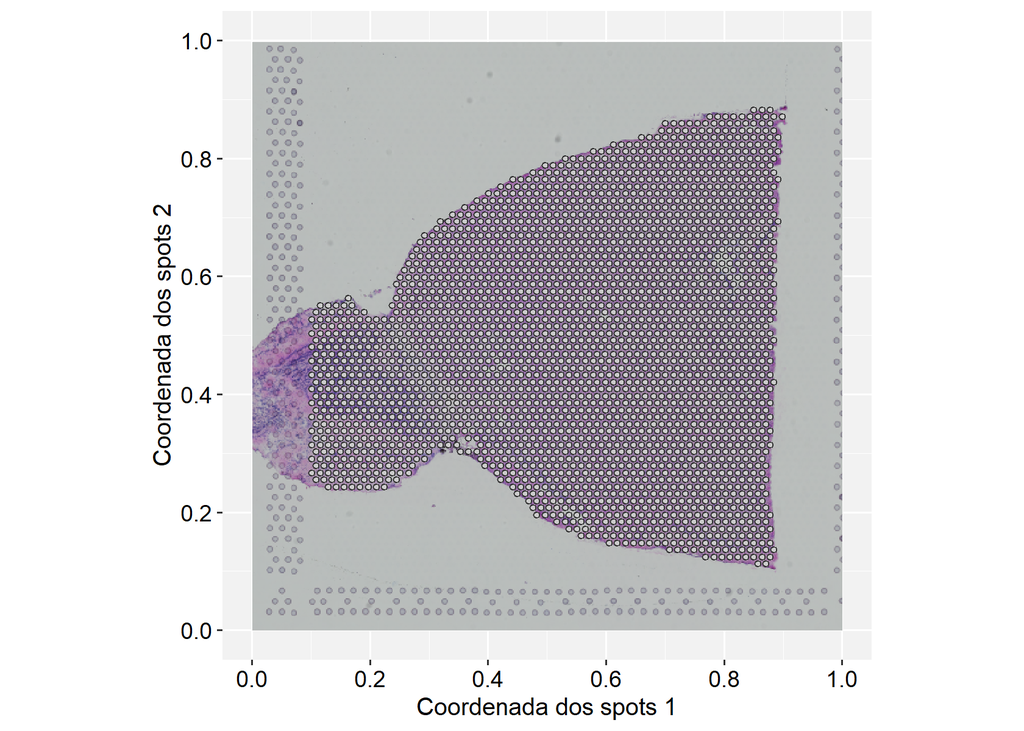

```r
xy_labs <- labs(x = "Coordenada dos spots 1",y = "Coordenada dos spots 2")

plotGraphSpace(gs,add.image = TRUE) +
  xy_labs
```

## 6.5 Plotagem com RGraphSpace

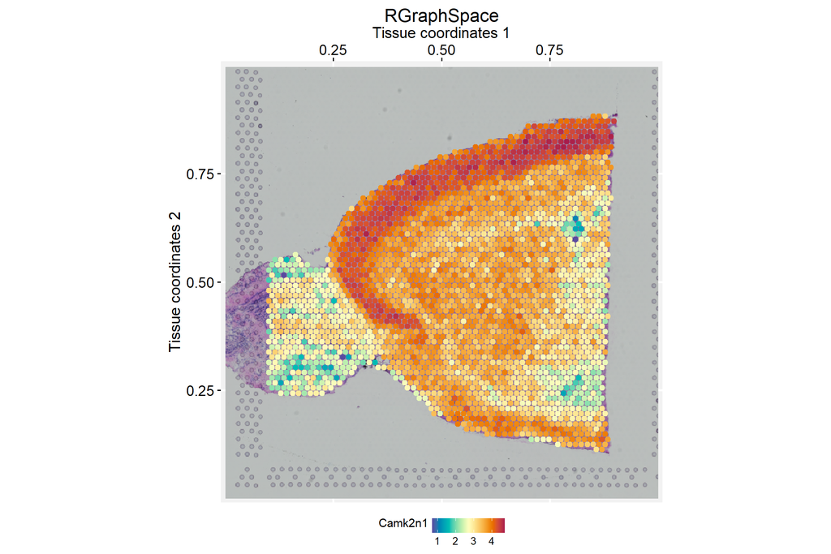

```r
cpal <- hcl.colors(100, palette = "Spectral", rev = TRUE)

g <- ggplot(gs) +
  annotation_gspace_image(gs) +
  geom_nodespace(mapping = aes(colour = Camk2n1), size = 1.2, pch = 19) +
            #Altere tamanho do spot em size para melhorar a visualização
  scale_colour_continuous(palette = cpal) +
  theme_gspace_coords(theme = "th3", is_norm = TRUE,
    xlab = "Tissue coordinates 1", ylab = "Tissue coordinates 2") +
  labs(title = "RGraphSpace")
g
```

```r
ggsave(filename = file.path(
    diretorio_imagens,
    "Brain_ant_RGraphSpace_Camk2n1.png"
  ),plot = g,width = 5,height = 5,units = "in",dpi = 120,bg = "white")
```

# 7 Construir o PathwaySpace

O pacote [PathwaySpace](https://sysbiolab.github.io/PathwaySpace/articles/get-started.html) também é um desenvolvimento do Sysbiolab (é do BR de novo!!). Esse pacote é focado na projeção de sinal que permite realizar a visualização contínua de dados transcriptômica espacial. Com essa projeção é possível “preencher” os espaços entre os spots que não se conhece o sinal.

## 7.1 Calcular a distância entre spots

O `PathwaySpace` é construído a partir do objeto `GraphSpace`. A distância média de cada spot ao seu vizinho mais próximo (`pdist`) será usada como referência espacial pela função de decaimento da projeção.

```r
pspace_obj <- buildPathwaySpace(gs)
```

```
#> Validating arguments...
#> Creating a 'PathwaySpace' object...
```

```r
nspot <- getNearestNode(pspace_obj)

pdist <- mean(nspot$dist)
pdist
```

```
#> [1] 0.0135778
```

`pdist` é a média das distâncias (euclidianas) entre os spots e seus vizinhos mais próximos. No caso de Visium v1/v2 essa distância relativa do sistema de coordenadas normalizado seria comparável à 100um (distância entre os centros dos spots nessa versão da plataforma).

## 7.2 Mapear a silhueta do tecido

A silhueta delimita a área sobre a qual o sinal será projetado. O valor de base controla a extensão inicial dessa representação em torno do grafo.

```r
pspace_obj <- silhouetteMapping(pspace_obj,baseline = 0.1)
```

```
#> Validating arguments...
#> Mapping graph silhouette...
#> Mapping 'x' and 'y' coordinates...
#> Silhouette: 47.52% of the landscape area!
```

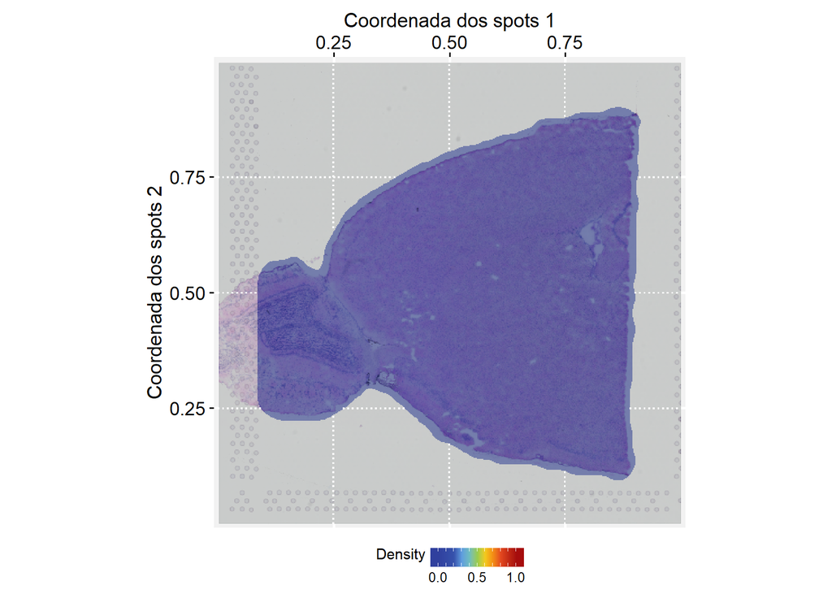

```r
plotPathwaySpace(ps = pspace_obj,
  theme = "th3",add.image = TRUE,si.alpha = 0.5) +
  xy_labs
```

# 8 Projetar o sinal gênico

A expressão de `Camk2n1` é associada aos vértices correspondentes aos spots. A projeção circular espalha esse sinal no espaço contínuo, ponderando a contribuição de cada spot pela distância e agregando as contribuições por média ponderada.

```r
# Informar nome do gene de interesse para plotar
activeFeature(pspace_obj) <- "Camk2n1"
```

```
#> Setting active feature 'Camk2n1' from feature matrix...
```

```r
pspace_obj <- circularProjection(pspace_obj,
  k = gs_vcount(pspace_obj),
  decay.fun = weibullDecay(decay = 0.5,pdist = pdist),
  aggregate.fun = signalAggregation("wmean"))
```

```
#> Validating arguments...
#> Using circular projection...
#> Mapping 'x' and 'y' coordinates...
#> Running signal convolution...
```

Aqui a projeção foi calculada e armazenada no objeto. A projeção depende de duas funções: decaimento e agregação. Caso queira entender melhor como elas funcionam, por favor acesse as vinhetas introdutórias do pacote: [PathwaySpace](https://sysbiolab.github.io/PathwaySpace/articles/get-started.html).